# Shock comparison

Juho Koistinen

2022-09-28

# Introduction and preliminaries

This document summarizes the results from different VAR specifications, which use different monetary policy shock measures to uncover the dynamic effects of monetary policy.

The benchmark VAR consists of four widely used monetary policy variables:
$$z_t = (100\cdot\log IP_t, 100\cdot\log CPI_t,EBP_t, FFR_t)'.$$
The underlying assumption is that the policy equation is given as
$$FFR_t = f(\Omega_t)+\varepsilon_t^{mp},$$
where the deviation from the policy rate can be divided into a true surprise and anticipated component, known by public $q$ months ahead

$$\varepsilon_t^{mp} = \varepsilon_t^{mps} + \varepsilon_{t-q}^{news}.$$

To identify both components of the error to $FFR_t$, the baseline VAR is augmented with a monetary policy residual, $MPR_t\approx\varepsilon_t^{mps}+\varepsilon_{t-q}^{news}$, which reveals the monetary news/forward guidance component:
$$y_t = (z_t', MPR_t)'.$$

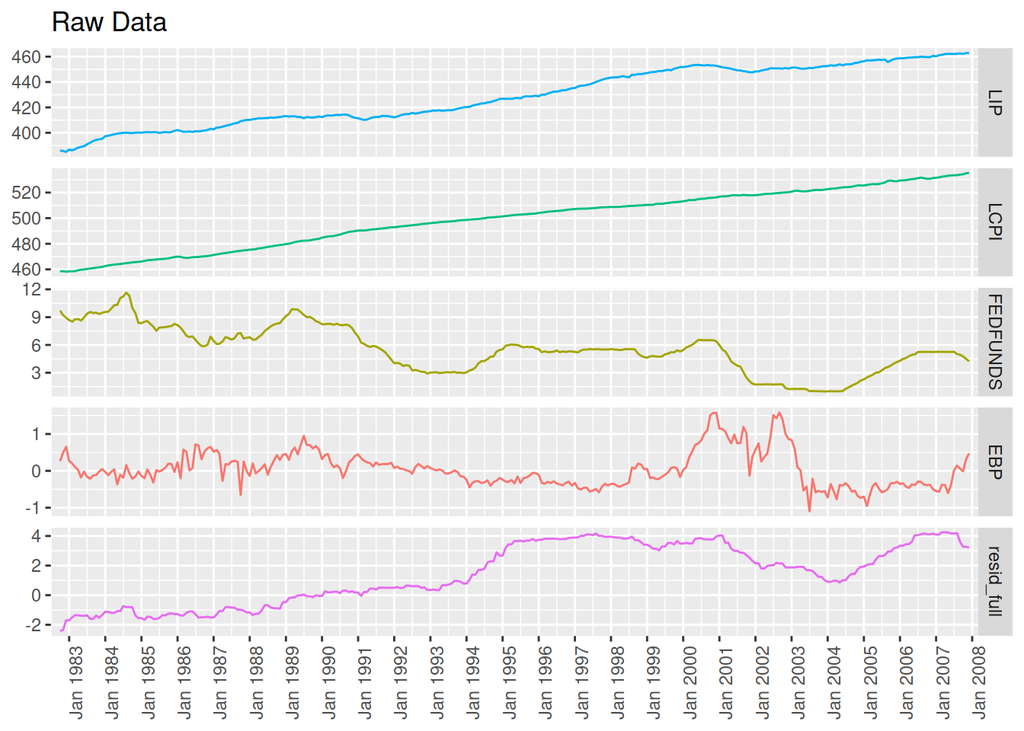

# Identification

We entertain three identification schemes:

1. Internal instrument/recursive. $MPS_t$ is ordered first and the model is identified recursively. This gives results consistent with the external instrument/Proxy-SVAR approach. Only the conventional MP shock is identified and this is primarily used for comparison to the results using identification by non-Gaussianity.
2. Identification by non-Gaussianity. The aim is to identify structural shocks both to $FFR_t$ and $MPS_t$, where the former is the conventional and the latter is an anticipated monetary news shock. The identification is achieved by assuming shock non-Gaussianity combined with the short-run restriction that the news shock does not have contemporaneous effect on $MPS_t$.
3. FEVD. Only news shock is identified using this method. This method identifies the news shock as the one that maximizes the FEV of $MPR_t$ in a given forecast horizon. Details [here](https://assets.aeaweb.org/asset-server/articles-attachments/aer/data/oct2013/20110331_app.pdf).

# 2y Gov’t bond

```r
rbind(
  stat = sapply(apply(irf_ng$resids, 2, shapiro.test), function(x) x$statistic),
  pval = sapply(apply(irf_ng$resids, 2, shapiro.test), function(x) x$p.value)
) %>% round(4) %>% DT::datatable(colnames = c("MPR", "LIP", "LCPI", "EBP", "FEDFUNDS"))
```

|  | MPR | LIP | LCPI | EBP | FEDFUNDS |
| --- | --- | --- | --- | --- | --- |
| stat | 0.9901 | 0.9499 | 0.9732 | 0.9438 | 0.922 |
| pval | 0.0062 | 0 | 0 | 0 | 0 |

```r
rbind(
  stat = sapply(apply(irf_ng$resids, 2, Box.test, lag = 12), function(x) x$statistic),
  pval = sapply(apply(irf_ng$resids, 2, Box.test, lag = 12), function(x) x$p.value)
) %>% round(4) %>% DT::datatable(colnames = c("MPR", "LIP", "LCPI", "EBP", "FEDFUNDS"))
```

|  | MPR | LIP | LCPI | EBP | FEDFUNDS |
| --- | --- | --- | --- | --- | --- |
| stat | 7.417 | 2.3723 | 8.6765 | 1.1247 | 2.2493 |
| pval | 0.8289 | 0.9986 | 0.7303 | 1 | 0.9989 |

```r
rbind(
  stat = sapply(apply(irf_ng$resids**2, 2, Box.test, lag = 12), function(x) x$statistic),
  pval = sapply(apply(irf_ng$resids**2, 2, Box.test, lag = 12), function(x) x$p.value)
) %>% round(4) %>% DT::datatable(colnames = c("MPR", "LIP", "LCPI", "EBP", "FEDFUNDS"))
```

|  | MPR | LIP | LCPI | EBP | FEDFUNDS |
| --- | --- | --- | --- | --- | --- |
| stat | 50.6728 | 16.2691 | 32.0179 | 13.5566 | 105.4516 |
| pval | 0 | 0.1792 | 0.0014 | 0.3299 | 0 |

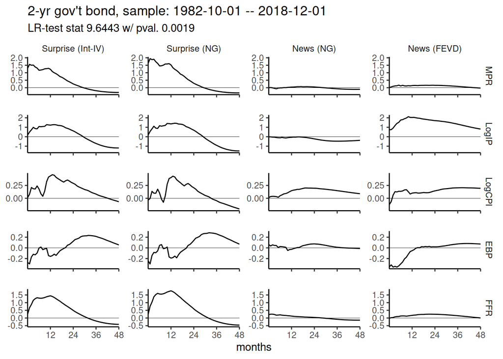

# Romer and Romer (2004)

The Romer and Romer (2004) shock is expected to be short-lived and not to contain a forward guidance component, which would show up in the delayed response of FFR.

```r
rbind(
  stat = sapply(apply(irf_ng$resids, 2, shapiro.test), function(x) x$statistic),
  pval = sapply(apply(irf_ng$resids, 2, shapiro.test), function(x) x$p.value)
) %>% round(4) %>% DT::datatable(colnames = c("MPR", "LIP", "LCPI", "EBP", "FEDFUNDS"))
```

|  | MPR | LIP | LCPI | EBP | FEDFUNDS |
| --- | --- | --- | --- | --- | --- |
| stat | 0.9889 | 0.9853 | 0.9678 | 0.964 | 0.9412 |
| pval | 0.0259 | 0.0045 | 0 | 0 | 0 |

```r
rbind(
  stat = sapply(apply(irf_ng$resids, 2, Box.test, lag = 12), function(x) x$statistic),
  pval = sapply(apply(irf_ng$resids, 2, Box.test, lag = 12), function(x) x$p.value)
) %>% round(4) %>% DT::datatable(colnames = c("MPR", "LIP", "LCPI", "EBP", "FEDFUNDS"))
```

|  | MPR | LIP | LCPI | EBP | FEDFUNDS |
| --- | --- | --- | --- | --- | --- |
| stat | 2.9836 | 2.3349 | 15.7945 | 3.0116 | 2.0196 |
| pval | 0.9957 | 0.9987 | 0.2008 | 0.9955 | 0.9994 |

```r
rbind(
  stat = sapply(apply(irf_ng$resids**2, 2, Box.test, lag = 12), function(x) x$statistic),
  pval = sapply(apply(irf_ng$resids**2, 2, Box.test, lag = 12), function(x) x$p.value)
) %>% round(4) %>% DT::datatable(colnames = c("MPR", "LIP", "LCPI", "EBP", "FEDFUNDS"))
```

|  | MPR | LIP | LCPI | EBP | FEDFUNDS |
| --- | --- | --- | --- | --- | --- |
| stat | 6.8856 | 16.7581 | 22.0376 | 45.5462 | 44.9407 |
| pval | 0.8651 | 0.1589 | 0.0371 | 0 | 0 |

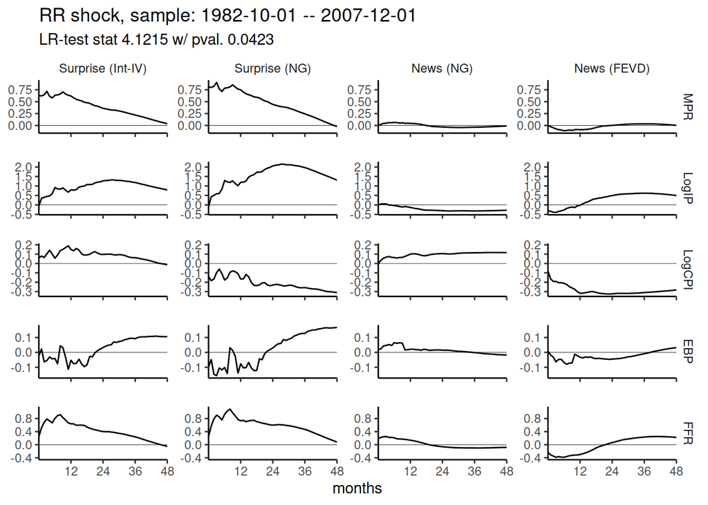

# Gertler and Karadi (2015)

```r
rbind(
  stat = sapply(apply(irf_ng$resids, 2, shapiro.test), function(x) x$statistic),
  pval = sapply(apply(irf_ng$resids, 2, shapiro.test), function(x) x$p.value)
) %>% round(4) %>% DT::datatable(colnames = c("MPR", "LIP", "LCPI", "EBP", "FEDFUNDS"))
```

|  | MPR | LIP | LCPI | EBP | FEDFUNDS |
| --- | --- | --- | --- | --- | --- |
| stat | 0.8966 | 0.9712 | 0.9797 | 0.9747 | 0.9685 |
| pval | 0 | 0 | 0.0006 | 0.0001 | 0 |

```r
rbind(
  stat = sapply(apply(irf_ng$resids, 2, Box.test, lag = 12), function(x) x$statistic),
  pval = sapply(apply(irf_ng$resids, 2, Box.test, lag = 12), function(x) x$p.value)
) %>% round(4) %>% DT::datatable(colnames = c("MPR", "LIP", "LCPI", "EBP", "FEDFUNDS"))
```

|  | MPR | LIP | LCPI | EBP | FEDFUNDS |
| --- | --- | --- | --- | --- | --- |
| stat | 3.7206 | 4.1528 | 11.173 | 4.7089 | 1.8151 |
| pval | 0.988 | 0.9805 | 0.5142 | 0.967 | 0.9996 |

```r
rbind(
  stat = sapply(apply(irf_ng$resids**2, 2, Box.test, lag = 12), function(x) x$statistic),
  pval = sapply(apply(irf_ng$resids**2, 2, Box.test, lag = 12), function(x) x$p.value)
) %>% round(4) %>% DT::datatable(colnames = c("MPR", "LIP", "LCPI", "EBP", "FEDFUNDS"))
```

|  | MPR | LIP | LCPI | EBP | FEDFUNDS |
| --- | --- | --- | --- | --- | --- |
| stat | 13.4674 | 14.3806 | 32.4725 | 32.2237 | 9.2589 |
| pval | 0.336 | 0.2771 | 0.0012 | 0.0013 | 0.6807 |

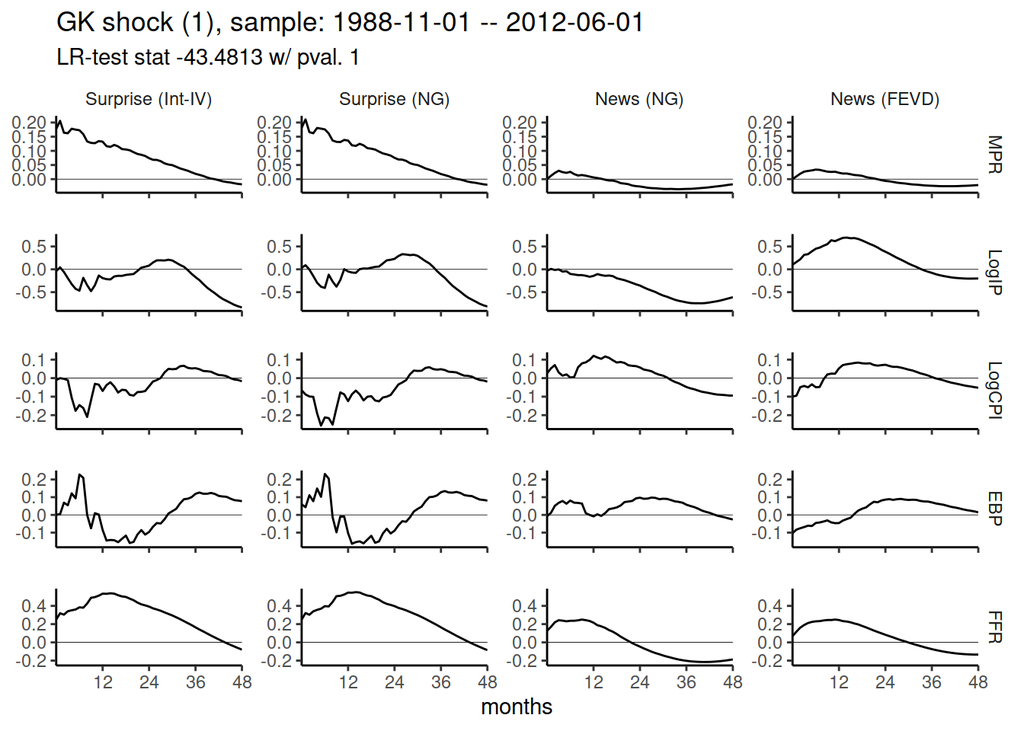

```r
rbind(
  stat = sapply(apply(irf_ng$resids, 2, shapiro.test), function(x) x$statistic),
  pval = sapply(apply(irf_ng$resids, 2, shapiro.test), function(x) x$p.value)
) %>% round(4) %>% DT::datatable(colnames = c("MPR", "LIP", "LCPI", "EBP", "FEDFUNDS"))
```

|  | MPR | LIP | LCPI | EBP | FEDFUNDS |
| --- | --- | --- | --- | --- | --- |
| stat | 0.8742 | 0.9608 | 0.9783 | 0.9838 | 0.9642 |
| pval | 0 | 0 | 0.0006 | 0.0051 | 0 |

```r
rbind(
  stat = sapply(apply(irf_ng$resids, 2, Box.test, lag = 12), function(x) x$statistic),
  pval = sapply(apply(irf_ng$resids, 2, Box.test, lag = 12), function(x) x$p.value)
) %>% round(4) %>% DT::datatable(colnames = c("MPR", "LIP", "LCPI", "EBP", "FEDFUNDS"))
```

|  | MPR | LIP | LCPI | EBP | FEDFUNDS |
| --- | --- | --- | --- | --- | --- |
| stat | 3.6155 | 6.6161 | 11.6852 | 4.081 | 2.2797 |
| pval | 0.9894 | 0.8819 | 0.4713 | 0.9819 | 0.9988 |

```r
rbind(
  stat = sapply(apply(irf_ng$resids**2, 2, Box.test, lag = 12), function(x) x$statistic),
  pval = sapply(apply(irf_ng$resids**2, 2, Box.test, lag = 12), function(x) x$p.value)
) %>% round(4) %>% DT::datatable(colnames = c("MPR", "LIP", "LCPI", "EBP", "FEDFUNDS"))
```

|  | MPR | LIP | LCPI | EBP | FEDFUNDS |
| --- | --- | --- | --- | --- | --- |
| stat | 10.2967 | 10.0529 | 34.8635 | 26.3558 | 10.4177 |
| pval | 0.59 | 0.6113 | 0.0005 | 0.0096 | 0.5794 |

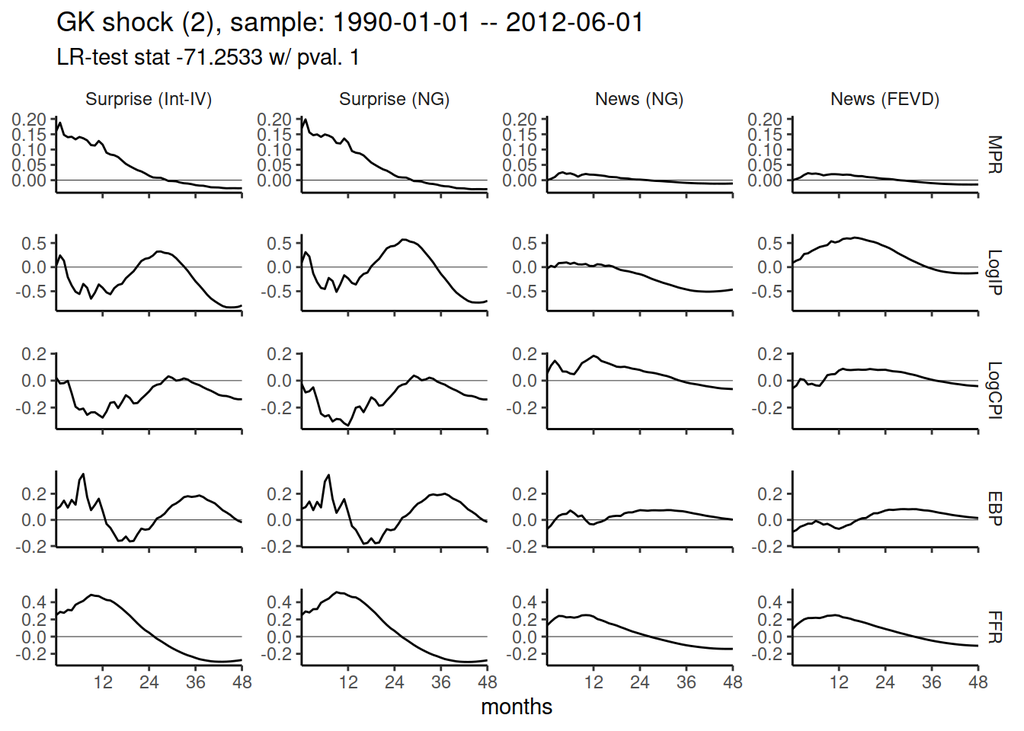

# Bu, Rogers and Wu (2021)

```r
rbind(
  stat = sapply(apply(irf_ng$resids, 2, shapiro.test), function(x) x$statistic),
  pval = sapply(apply(irf_ng$resids, 2, shapiro.test), function(x) x$p.value)
) %>% round(4) %>% DT::datatable(colnames = c("MPR", "LIP", "LCPI", "EBP", "FEDFUNDS"))
```

|  | MPR | LIP | LCPI | EBP | FEDFUNDS |
| --- | --- | --- | --- | --- | --- |
| stat | 0.9719 | 0.9498 | 0.9812 | 0.9622 | 0.9834 |
| pval | 0 | 0 | 0.0006 | 0 | 0.0015 |

```r
rbind(
  stat = sapply(apply(irf_ng$resids, 2, Box.test, lag = 12), function(x) x$statistic),
  pval = sapply(apply(irf_ng$resids, 2, Box.test, lag = 12), function(x) x$p.value)
) %>% round(4) %>% DT::datatable(colnames = c("MPR", "LIP", "LCPI", "EBP", "FEDFUNDS"))
```

|  | MPR | LIP | LCPI | EBP | FEDFUNDS |
| --- | --- | --- | --- | --- | --- |
| stat | 6.8228 | 1.7363 | 9.4008 | 2.8681 | 4.1588 |
| pval | 0.8691 | 0.9997 | 0.6684 | 0.9964 | 0.9804 |

```r
rbind(
  stat = sapply(apply(irf_ng$resids**2, 2, Box.test, lag = 12), function(x) x$statistic),
  pval = sapply(apply(irf_ng$resids**2, 2, Box.test, lag = 12), function(x) x$p.value)
) %>% round(4) %>% DT::datatable(colnames = c("MPR", "LIP", "LCPI", "EBP", "FEDFUNDS"))
```

|  | MPR | LIP | LCPI | EBP | FEDFUNDS |
| --- | --- | --- | --- | --- | --- |
| stat | 25.0725 | 11.0927 | 13.9996 | 29.7471 | 42.2917 |
| pval | 0.0145 | 0.521 | 0.3007 | 0.003 | 0 |

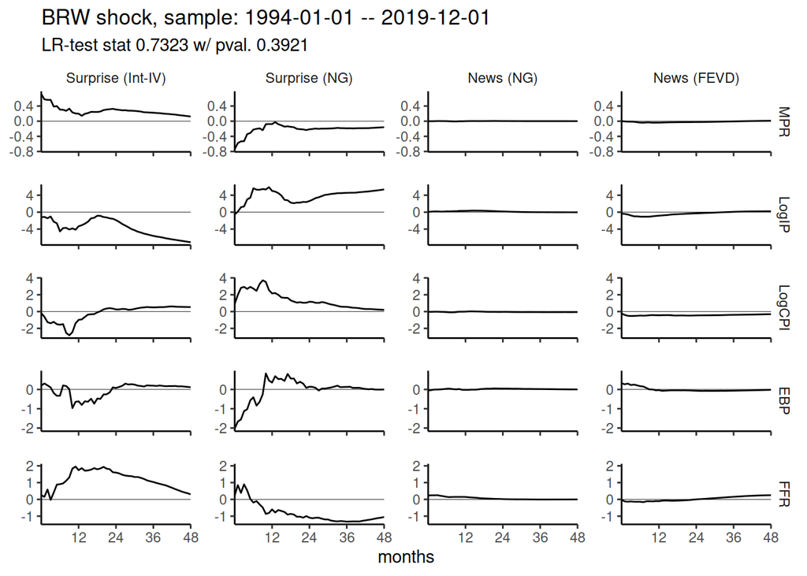

# Miranda-Agrippino and Ricco (2021)

```r
rbind(
  stat = sapply(apply(irf_ng$resids, 2, shapiro.test), function(x) x$statistic),
  pval = sapply(apply(irf_ng$resids, 2, shapiro.test), function(x) x$p.value)
) %>% round(4) %>% DT::datatable(colnames = c("MPR", "LIP", "LCPI", "EBP", "FEDFUNDS"))
```

|  | MPR | LIP | LCPI | EBP | FEDFUNDS |
| --- | --- | --- | --- | --- | --- |
| stat | 0.8976 | 0.9487 | 0.9808 | 0.9886 | 0.984 |
| pval | 0 | 0 | 0.0049 | 0.0825 | 0.0151 |

```r
rbind(
  stat = sapply(apply(irf_ng$resids, 2, Box.test, lag = 12), function(x) x$statistic),
  pval = sapply(apply(irf_ng$resids, 2, Box.test, lag = 12), function(x) x$p.value)
) %>% round(4) %>% DT::datatable(colnames = c("MPR", "LIP", "LCPI", "EBP", "FEDFUNDS"))
```

|  | MPR | LIP | LCPI | EBP | FEDFUNDS |
| --- | --- | --- | --- | --- | --- |
| stat | 1.7241 | 8.3829 | 5.7806 | 5.1044 | 2.0995 |
| pval | 0.9997 | 0.7545 | 0.9267 | 0.9544 | 0.9992 |

```r
rbind(
  stat = sapply(apply(irf_ng$resids**2, 2, Box.test, lag = 12), function(x) x$statistic),
  pval = sapply(apply(irf_ng$resids**2, 2, Box.test, lag = 12), function(x) x$p.value)
) %>% round(4) %>% DT::datatable(colnames = c("MPR", "LIP", "LCPI", "EBP", "FEDFUNDS"))
```

|  | MPR | LIP | LCPI | EBP | FEDFUNDS |
| --- | --- | --- | --- | --- | --- |
| stat | 2.3216 | 5.962 | 16.8887 | 19.1471 | 8.656 |
| pval | 0.9987 | 0.918 | 0.1538 | 0.085 | 0.732 |

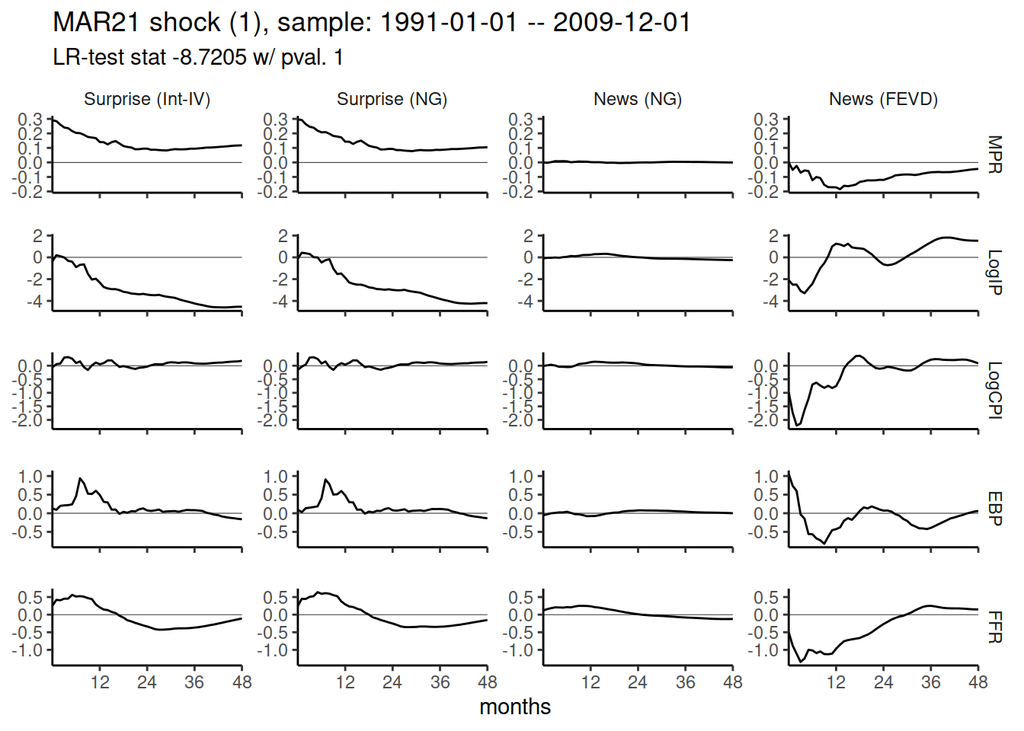

```r
rbind(
  stat = sapply(apply(irf_ng$resids, 2, shapiro.test), function(x) x$statistic),
  pval = sapply(apply(irf_ng$resids, 2, shapiro.test), function(x) x$p.value)
) %>% round(4) %>% DT::datatable(colnames = c("MPR", "LIP", "LCPI", "EBP", "FEDFUNDS"))
```

|  | MPR | LIP | LCPI | EBP | FEDFUNDS |
| --- | --- | --- | --- | --- | --- |
| stat | 0.9164 | 0.9398 | 0.9817 | 0.9661 | 0.9735 |
| pval | 0 | 0 | 0.0067 | 0 | 0.0004 |

```r
rbind(
  stat = sapply(apply(irf_ng$resids, 2, Box.test, lag = 12), function(x) x$statistic),
  pval = sapply(apply(irf_ng$resids, 2, Box.test, lag = 12), function(x) x$p.value)
) %>% round(4) %>% DT::datatable(colnames = c("MPR", "LIP", "LCPI", "EBP", "FEDFUNDS"))
```

|  | MPR | LIP | LCPI | EBP | FEDFUNDS |
| --- | --- | --- | --- | --- | --- |
| stat | 3.6354 | 7.9393 | 7.4906 | 6.9139 | 2.1703 |
| pval | 0.9892 | 0.7899 | 0.8236 | 0.8632 | 0.9991 |

```r
rbind(
  stat = sapply(apply(irf_ng$resids**2, 2, Box.test, lag = 12), function(x) x$statistic),
  pval = sapply(apply(irf_ng$resids**2, 2, Box.test, lag = 12), function(x) x$p.value)
) %>% round(4) %>% DT::datatable(colnames = c("MPR", "LIP", "LCPI", "EBP", "FEDFUNDS"))
```

|  | MPR | LIP | LCPI | EBP | FEDFUNDS |
| --- | --- | --- | --- | --- | --- |
| stat | 3.1278 | 8.0483 | 20.5883 | 9.0255 | 4.8878 |
| pval | 0.9946 | 0.7813 | 0.0567 | 0.7008 | 0.9616 |

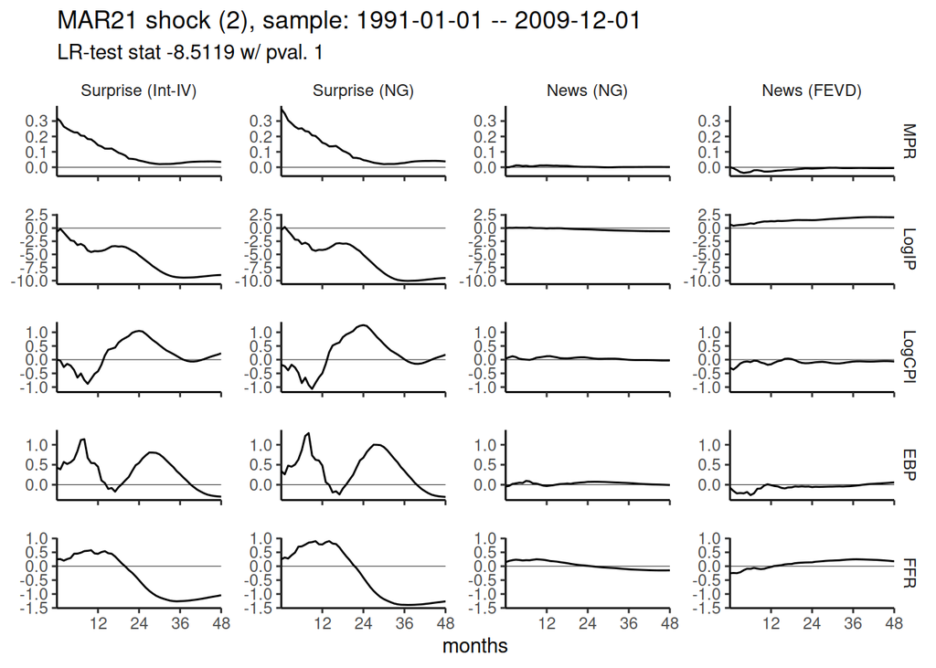

# Jarocinski (2022)

```r
rbind(
  stat = sapply(apply(irf_ng$resids, 2, shapiro.test), function(x) x$statistic),
  pval = sapply(apply(irf_ng$resids, 2, shapiro.test), function(x) x$p.value)
) %>% round(4) %>% DT::datatable(colnames = c("MPR", "LIP", "LCPI", "EBP", "FEDFUNDS"))
```

|  | MPR | LIP | LCPI | EBP | FEDFUNDS |
| --- | --- | --- | --- | --- | --- |
| stat | 0.83 | 0.9527 | 0.9793 | 0.9812 | 0.9519 |
| pval | 0 | 0 | 0.0001 | 0.0003 | 0 |

```r
rbind(
  stat = sapply(apply(irf_ng$resids, 2, Box.test, lag = 12), function(x) x$statistic),
  pval = sapply(apply(irf_ng$resids, 2, Box.test, lag = 12), function(x) x$p.value)
) %>% round(4) %>% DT::datatable(colnames = c("MPR", "LIP", "LCPI", "EBP", "FEDFUNDS"))
```

|  | MPR | LIP | LCPI | EBP | FEDFUNDS |
| --- | --- | --- | --- | --- | --- |
| stat | 3.9316 | 3.1845 | 10.3179 | 3.5206 | 3.5433 |
| pval | 0.9846 | 0.9941 | 0.5881 | 0.9906 | 0.9903 |

```r
rbind(
  stat = sapply(apply(irf_ng$resids**2, 2, Box.test, lag = 12), function(x) x$statistic),
  pval = sapply(apply(irf_ng$resids**2, 2, Box.test, lag = 12), function(x) x$p.value)
) %>% round(4) %>% DT::datatable(colnames = c("MPR", "LIP", "LCPI", "EBP", "FEDFUNDS"))
```

|  | MPR | LIP | LCPI | EBP | FEDFUNDS |
| --- | --- | --- | --- | --- | --- |
| stat | 14.5874 | 8.4999 | 22.9379 | 39.4897 | 38.5824 |
| pval | 0.2648 | 0.7449 | 0.0283 | 0.0001 | 0.0001 |

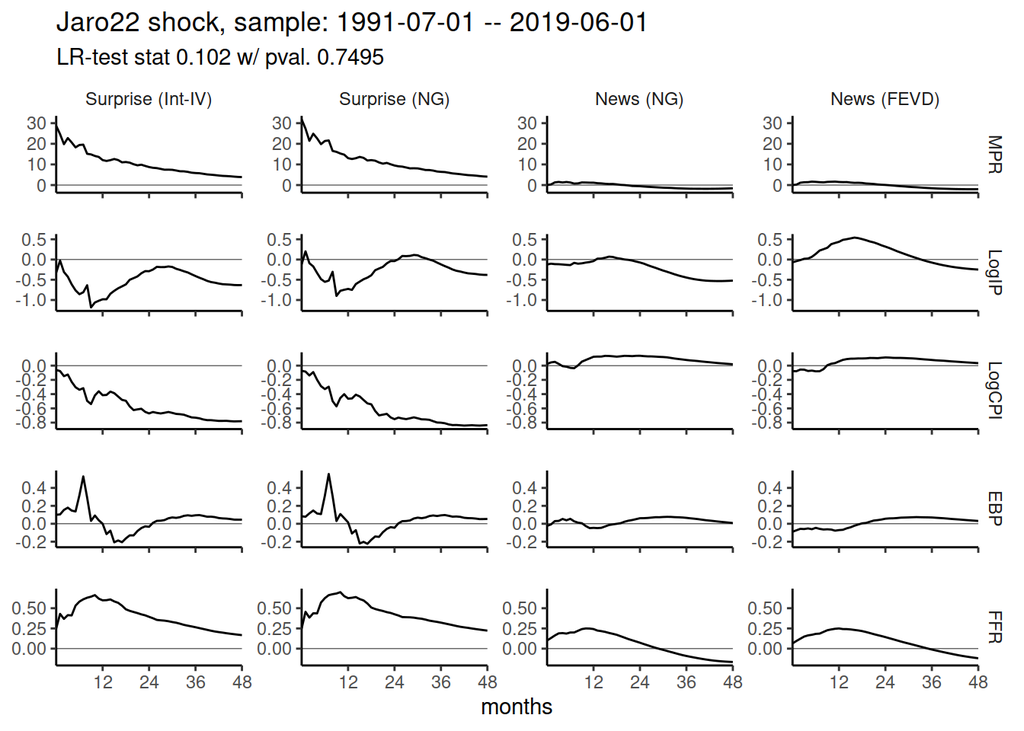

# Aruoba and Drechsel (2022)

```r
rbind(
  stat = sapply(apply(irf_ng$resids, 2, shapiro.test), function(x) x$statistic),
  pval = sapply(apply(irf_ng$resids, 2, shapiro.test), function(x) x$p.value)
) %>% round(4) %>% DT::datatable(colnames = c("MPR", "LIP", "LCPI", "EBP", "FEDFUNDS"))
```

|  | MPR | LIP | LCPI | EBP | FEDFUNDS |
| --- | --- | --- | --- | --- | --- |
| stat | 0.9811 | 0.9448 | 0.9776 | 0.9535 | 0.93 |
| pval | 0.0005 | 0 | 0.0001 | 0 | 0 |

```r
rbind(
  stat = sapply(apply(irf_ng$resids, 2, Box.test, lag = 12), function(x) x$statistic),
  pval = sapply(apply(irf_ng$resids, 2, Box.test, lag = 12), function(x) x$p.value)
) %>% round(4) %>% DT::datatable(colnames = c("MPR", "LIP", "LCPI", "EBP", "FEDFUNDS"))
```

|  | MPR | LIP | LCPI | EBP | FEDFUNDS |
| --- | --- | --- | --- | --- | --- |
| stat | 1.6635 | 3.4848 | 10.3053 | 1.2704 | 2.0431 |
| pval | 0.9998 | 0.991 | 0.5892 | 0.9999 | 0.9993 |

```r
rbind(
  stat = sapply(apply(irf_ng$resids**2, 2, Box.test, lag = 12), function(x) x$statistic),
  pval = sapply(apply(irf_ng$resids**2, 2, Box.test, lag = 12), function(x) x$p.value)
) %>% round(4) %>% DT::datatable(colnames = c("MPR", "LIP", "LCPI", "EBP", "FEDFUNDS"))
```

|  | MPR | LIP | LCPI | EBP | FEDFUNDS |
| --- | --- | --- | --- | --- | --- |
| stat | 22.6081 | 16.9092 | 22.489 | 18.8148 | 29.328 |
| pval | 0.0312 | 0.153 | 0.0324 | 0.0931 | 0.0035 |

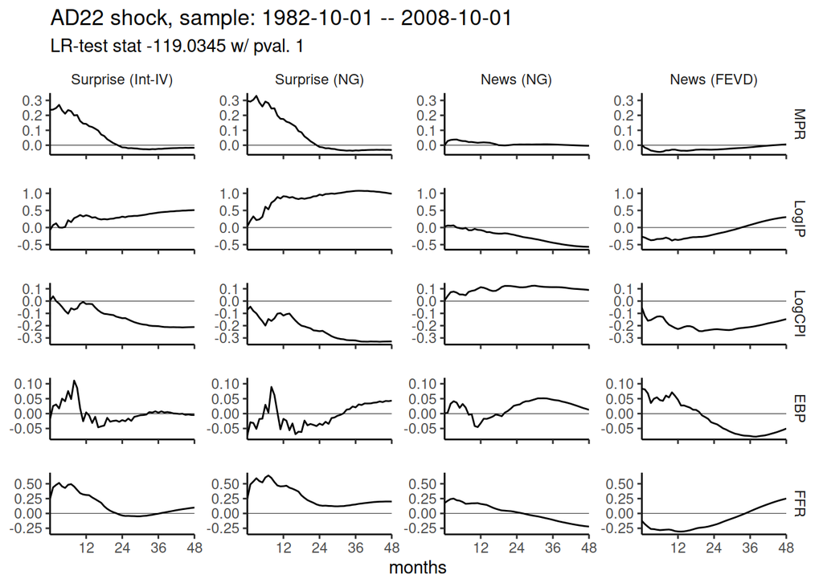

# Bauer and Swanson (2022)

```r
rbind(
  stat = sapply(apply(irf_ng$resids, 2, shapiro.test), function(x) x$statistic),
  pval = sapply(apply(irf_ng$resids, 2, shapiro.test), function(x) x$p.value)
) %>% round(4) %>% DT::datatable(colnames = c("MPR", "LIP", "LCPI", "EBP", "FEDFUNDS"))
```

|  | MPR | LIP | LCPI | EBP | FEDFUNDS |
| --- | --- | --- | --- | --- | --- |
| stat | 0.8959 | 0.963 | 0.9747 | 0.9726 | 0.9615 |
| pval | 0 | 0 | 0 | 0 | 0 |

```r
rbind(
  stat = sapply(apply(irf_ng$resids, 2, Box.test, lag = 12), function(x) x$statistic),
  pval = sapply(apply(irf_ng$resids, 2, Box.test, lag = 12), function(x) x$p.value)
) %>% round(4) %>% DT::datatable(colnames = c("MPR", "LIP", "LCPI", "EBP", "FEDFUNDS"))
```

|  | MPR | LIP | LCPI | EBP | FEDFUNDS |
| --- | --- | --- | --- | --- | --- |
| stat | 3.089 | 2.1205 | 9.7913 | 3.3749 | 1.1389 |
| pval | 0.9949 | 0.9992 | 0.6343 | 0.9923 | 1 |

```r
rbind(
  stat = sapply(apply(irf_ng$resids**2, 2, Box.test, lag = 12), function(x) x$statistic),
  pval = sapply(apply(irf_ng$resids**2, 2, Box.test, lag = 12), function(x) x$p.value)
) %>% round(4) %>% DT::datatable(colnames = c("MPR", "LIP", "LCPI", "EBP", "FEDFUNDS"))
```

|  | MPR | LIP | LCPI | EBP | FEDFUNDS |
| --- | --- | --- | --- | --- | --- |
| stat | 10.8105 | 24.7018 | 23.973 | 50.2152 | 31.2998 |
| pval | 0.5452 | 0.0163 | 0.0205 | 0 | 0.0018 |

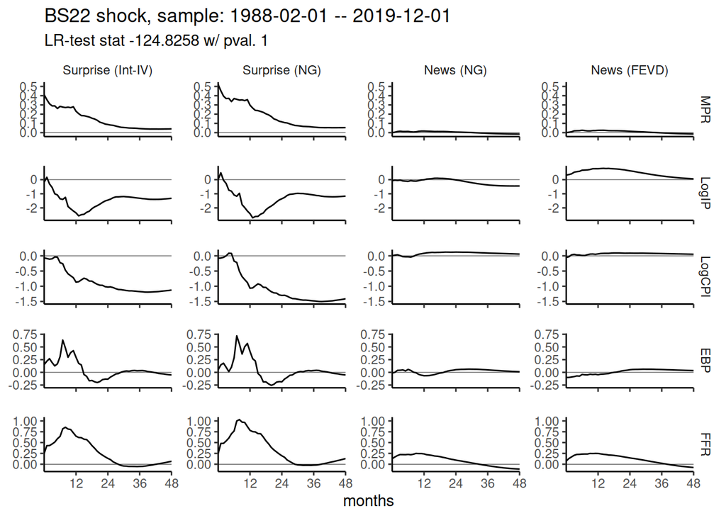

```r
rbind(
  stat = sapply(apply(irf_ng$resids, 2, shapiro.test), function(x) x$statistic),
  pval = sapply(apply(irf_ng$resids, 2, shapiro.test), function(x) x$p.value)
) %>% round(4) %>% DT::datatable(colnames = c("MPR", "LIP", "LCPI", "EBP", "FEDFUNDS"))
```

|  | MPR | LIP | LCPI | EBP | FEDFUNDS |
| --- | --- | --- | --- | --- | --- |
| stat | 0.9315 | 0.9598 | 0.9781 | 0.9739 | 0.9613 |
| pval | 0 | 0 | 0 | 0 | 0 |

```r
rbind(
  stat = sapply(apply(irf_ng$resids, 2, Box.test, lag = 12), function(x) x$statistic),
  pval = sapply(apply(irf_ng$resids, 2, Box.test, lag = 12), function(x) x$p.value)
) %>% round(4) %>% DT::datatable(colnames = c("MPR", "LIP", "LCPI", "EBP", "FEDFUNDS"))
```

|  | MPR | LIP | LCPI | EBP | FEDFUNDS |
| --- | --- | --- | --- | --- | --- |
| stat | 3.6948 | 1.1694 | 9.0599 | 2.418 | 1.8349 |
| pval | 0.9883 | 1 | 0.6978 | 0.9984 | 0.9996 |

```r
rbind(
  stat = sapply(apply(irf_ng$resids**2, 2, Box.test, lag = 12), function(x) x$statistic),
  pval = sapply(apply(irf_ng$resids**2, 2, Box.test, lag = 12), function(x) x$p.value)
) %>% round(4) %>% DT::datatable(colnames = c("MPR", "LIP", "LCPI", "EBP", "FEDFUNDS"))
```

|  | MPR | LIP | LCPI | EBP | FEDFUNDS |
| --- | --- | --- | --- | --- | --- |
| stat | 7.338 | 19.7174 | 25.1699 | 49.6417 | 30.9505 |
| pval | 0.8345 | 0.0726 | 0.014 | 0 | 0.002 |

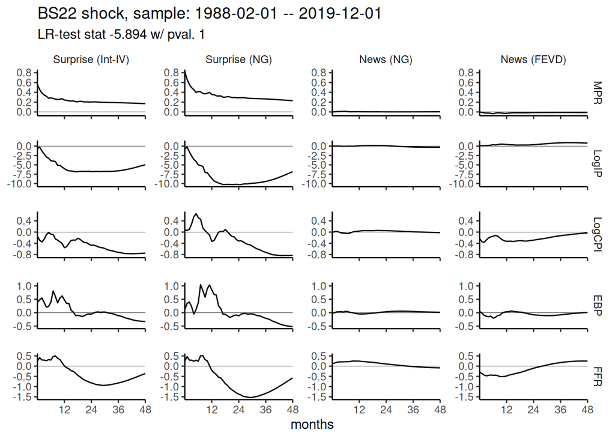